# Coxon_HW2

Victoria Coxon

September 20, 2015

# Homework 1

Guidelines: Homeworks should be clear and legible, with answers clearly indicated and work shown. Homeworks will be given a minus, check, or check plus owing to completion and correctness. You are welcome to work with others but please submit your own work. Your homework must be produced in an R Markdown (.rmd) file submitted via github.

If you are having trouble accomplishing this, please refer to the [guide](http://spia.uga.edu/faculty_pages/tyler.scott/teaching/PADP8120_Fall2015/Homeworks/submitting_homework.shtml).

This homework adapts materials from the work of Michael Lynch (http://spia.uga.edu/faculty_pages/mlynch/), Tyler McCormick (http://www.stat.washington.edu/~tylermc/), and Open Intro (https://www.openintro.org/stat/textbook.php)

## Problems

1. Being hit by a chair is a common occurrence in WWE professional wrestling. The number of people hit upside the head with chairs can vary from program to program. Suppose that the number of chair-bashings per program is Normally distributed, with mean thirty-five (35) bashings and standard deviation of eight (8) bashings. What is the probability that one WWE program will contain less than nineteen (19) bashings or more than forty (40) bashings?

```r
bashings.lowerpval <- pnorm(q=19,mean = 35, sd = 8, lower.tail = TRUE);bashings.lowerpval
```

```
## [1] 0.02275013
```

```r
bashings.upperpval <- pnorm(q=40,mean = 35, sd = 8, lower.tail = FALSE);bashings.upperpval
```

```
## [1] 0.2659855
```

```r
total.bashings <- bashings.lowerpval + bashings.upperpval; total.bashings
```

```
## [1] 0.2887357
```

When seeking to determine the probability within one WWE program (1 sample) of chair-bashing observations(x) of x < 19 or x > 40, the combined probability of either obsrvation is 0.2887357 or 0.289.

2. A corporation has just received new machinery that must be installed and checked before it becomes operational. The following table shows a manager’s probability assessment for the number of days required before the machinery becomes operational:

| Days | 5 | 6 | 7 | 8 | 9 | 10 |
| --- | --- | --- | --- | --- | --- | --- |
| Prob. | 0.06 | 0.21 | 0.37 | 0.20 | 0.13 | 0.06 |

Let A be the event “It will be more than 6 days before the machinery becomes operational,” and let B be the event “It will be less than 8 days before the machinery becomes available.”

1. Find the probability of event A.

```r
A.event <- 0.37 + 0.20 + 0.13 + 0.06; print(A.event)
```

```
## [1] 0.76
```

The probability of Event A, x > 6 days, is 0.76. There is a relatively high probability that the machinery will become operational after 6 days.

2. Find the probability of event B.

```r
B.event <- 0.06 + 0.21 + 0.37; print(B.event)
```

```
## [1] 0.64
```

The probability of Event B, x < 8 days, is 0.64. There is a relatively high probability that the machinery will become operational in under 8 days.

3. Find the probability of the complement of event A.

```r
complement.A <- 1 - A.event; print(complement.A)
```

```
## [1] 0.24
```

The probability that the machinery will be operational in under 6 days is 0.24.

4. Find the probability of the intersection of events A and B.

In all the listed probabilities for scenarios where the machinery becomes operational, this concerns the probability where 6 < x < 8. This corresponds to 7 days, hence the probability is 0.37.

5. Find the probability of the union of events A and B.

```r
AandB.event <- A.event + B.event - 0.37; print(AandB.event)
```

```
## [1] 1.03
```

3. An ultramarathon race official has found that 68% of first time entrants and 87% ofrepeat racers finish the race. Of all entrants, 64% are repeat racers and the remainders are first time entrants.
1. What is the probability that a randomly chosen entrant is a repeat racer who will eventually finish the race? Prob(repeat and finish) = 0.87 Prob(repeat and quit) = 1 - 0.87 = 0.13 Prob(first and finish) = 0.68 Prob(first and quit) = 1 - 0.68 = 0.32 Prob(repeat) = 0.64 Prob(first) = 1 - 0.64 = 0.36

```r
Prob.repeat.and.finish <- 0.87
Prob.repeat <- 0.64
random.repeat.and.finish <- 0.87 * 0.64; print(random.repeat.and.finish)
```

```
## [1] 0.5568
```

P(random.repeat.and.finish) = 0.5568 or 0.557.

2. Find the probability that a randomly chosen entrant will eventually finish the race.

```r
Prob.first.and.finish <- 0.68
Prob.first <- 0.36
random.first.and.finish <- 0.68 * 0.36; print(random.first.and.finish)
```

```
## [1] 0.2448
```

```r
random.finish <- random.repeat.and.finish + random.first.and.finish; print(random.finish)
```

```
## [1] 0.8016
```

The P(random.finish) = 0.8016 or 0.802.

3. What is the probability that a randomly chosen entrant either is a repeat racer or will eventually finish (or both)?

```r
repeat.or.finish <- Prob.repeat + random.finish - random.repeat.and.finish; print(repeat.or.finish)
```

```
## [1] 0.8848
```

The P(repeat.or.finish) = 0.8848 or 0.885.

4. A school received a grant to offer two extracurricular clubs, art and chess. Of the students 35% signed up for art club and 40% for chess club. Of those signing up for art club 20% signed up for chess club. Prob(art) = 0.35 Prob(chess) = 0.40 Prob(chess given art) = 0.20
1. What is the probability that a randomly selected student signed up for both clubs?

```r
Prob.art <- 0.35
Prob.chess <- 0.40
Prob.chess.given.art <- 0.20
random.chess.given.art <- Prob.art * Prob.chess.given.art; print(random.chess.given.art)
```

```
## [1] 0.07
```

2. What is the probability that a randomly selected student who signed up for chess club also signed up for art club?

```r
random.chess.and.art <- random.chess.given.art / Prob.chess; print(random.chess.and.art)
```

```
## [1] 0.175
```

The probability that a randomly selected student who signed up for chess club also signed up for art club is 0.175.

3. What is the probability that a randomly chosen student signed up for at least one of these two clubs?

```r
two.clubs <- Prob.art + Prob.chess - random.chess.given.art; print(two.clubs)
```

```
## [1] 0.68
```

The probability that a randomly chosen student signed up for at least one of these two clubs is 0.68.

5. Records show that 442 students recently entered a Florida public school district. Of those 442, 84 have not received their vaccinations. The district’s physician is scheduled to go from school to school next Tuesday to give shots to those who need them. If we know that about 8% of students are absent on any given day, how many unvaccinated students are likely to miss the doctor visit?

```r
Prob.no.vac <- 84/442; print(Prob.no.vac)
```

```
## [1] 0.1900452
```

```r
(8 * 442) / 100 #35.36 kids
```

```
## [1] 35.36
```

```r
Prob.absent <- 35/442; print(Prob.absent)
```

```
## [1] 0.07918552
```

```r
84 * Prob.absent
```

```
## [1] 6.651584
```

P(no.vac) = 0.1900452 P(absent) = 0.07918552 = 0.08

Working from the assumption that having unvaccinated status is not related to absenteeism, then P(no.vac) has no bearing on the P(absent). The unvaccinated kids will have the same chance of being absent as the rest of the kids in the sample where n = 442. The number of kids the district’s physician will miss is 6.651584 or 6 (because you cannnot have portions of kids; the variable is discrete).

6. For questions 1a - 1c, assume a variable is normally distributed with a mean of 180 and a standard deviation of 25. Please show all work (i.e., relevant code - hint: the `pnorm`/`qnorm`/`dnorm` family will be your friend here)
1. What is the probability that a single draw from this distribution, labeled X, will be greater than 210?

```r
#pnorm(CV,n,sd,lower.tail  = FALSE) -> if greater than mean
#              lower.tail = TRUE) -> if less than mean
pnorm(210,180,25,lower.tail = FALSE)
```

```
## [1] 0.1150697
```

The probabilty that a single draw where x > 210 from a normally distributed variable with a mean of 180 and a standard deviation of 25 is 0.1150697.

2. What is the probability that a single draw from this distribution, labeled Y, will be less than 182?

```r
pnorm(182,180,25,lower.tail = TRUE)
```

```
## [1] 0.5318814
```

The probability that a single draw from this distribution, labeled Y, will be less than 182 is 0.5318814.

3. What is the probability that a single draw from this distribution, labeled Z, will be between 160 and 192?

```r
1- (pnorm(160,180,25,lower.tail = TRUE) + pnorm(192,180,25,lower.tail = FALSE))
```

```
## [1] 0.4725309
```

The probability that a single draw from this distribution, labeled Z, will be between 160 and 192 is 0.4725309.

7. The random variable x has the discrete probability distribution shown here:

| x | -2 | -1 | 0 | 1 | 2 |
| --- | --- | --- | --- | --- | --- |
| p(x) | 0.15 | 0.15 | 0.35 | 0.25 | 0.10 |

1. Find $P(x<=0)$

```r
#Need to find sum of all p(x) values that are < or = to 0.
#P(x = -2) <- 0.15
#P(x = -1) <- 0.15
#P(x = 0)  <- 0.35
0.15 + 0.15 + 0.35
```

```
## [1] 0.65
```

The probability of P(x<=0) is 0.65,

2. Find $P(x>-1)$

```r
#Need to find the sum of all the p(x) values that are > -1.
#P(x = 0) <- 0.35
#P(x = 1) <- 0.25
#P(x = 2) <- 0.10
0.35 + 0.25 + 0.10
```

```
## [1] 0.7
```

The probability of P(x>-1) is 0.7.

3. Find $P(-1<=x<=1)$

```r
#Need to find the sum of all values p(x) between -1 and 1.
#P(x = -1) <- 0.15
#P(x = 0)  <- 0.35
#P(x = 1) <- 0.25
0.15 + 0.35 + 0.25
```

```
## [1] 0.75
```

The probabilty of P(-1<=x<=1) is 0.75.

4. Find $P(x<2)$

```r
#Need to find the sum  of p(x) values < 2.
#P(x = 1) <- 0.25
#P(x = 0) <- 0.35
#P(x = -1) <- 0.15
#P(x = -2) <- 0.15
0.25 + 0.35 + 0.15 + 0.15
```

```
## [1] 0.9
```

```r
#Alternatively, I can also use 1 - P(x = 2).
#P(x = 2) <- 0.10
1 - 0.10
```

```
## [1] 0.9
```

The probability of P(x<2) is 0.90.

5. Find $P(-1<x<2)$

```r
#Need to find the sum of all p(x) values between -1 and 2.
#P(x = 0)  <- 0.35
#P(x = 1) <- 0.25
0.35 + 0.25
```

```
## [1] 0.6
```

```r
#Alternatively I can also use 1 - [P(x = -1 ) + P(x = -2)] + [P(x = 2)]
#P(x = -2) <- 0.15
#P(x = -1) <- 0.15
#P(x = 2) <- 0.10
1 - (0.15 + 0.15 + 0.10)
```

```
## [1] 0.6
```

4. Experiment with increasing/decreasing the number of original samples (draws within one “sample”) and the number of re-samples (number of times you repeat the sampling process). Pay attention to the impact changing either has on the resulting distribution of sample means, and provide some form of visual demonstration (table and/or figure) to show how sample size changes your results.

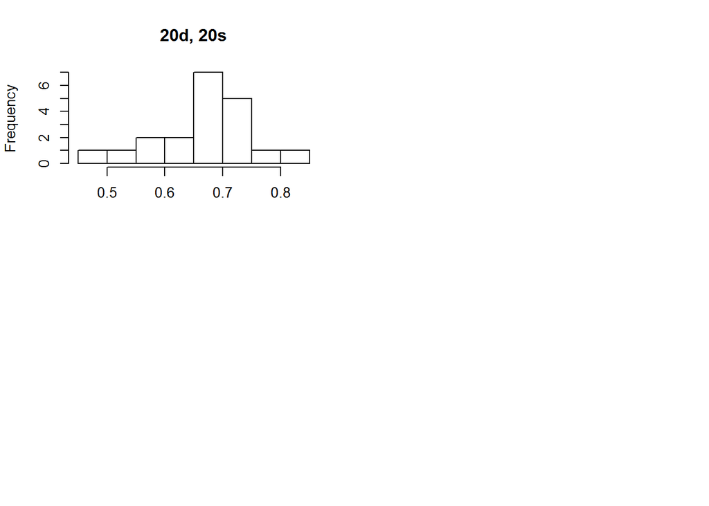

```r
#I am unsure as to how I need to structure this. I am relying heavily on the HW2 Key and copying verbatim.
?par
#par(..., no.readonly = FALSE)
#Still don't get it...
par(mfrow=c(2,2))
##GUIDE:  hist(replicate(# of repeats, mean(sample(x,# of draws, replace = TRUE if w/replacement)))main='Label of Histogram',xlab='')

# 20 draws repeated 20 times
hist(replicate(20,mean(sample(cflip,20,replace=T))),main='20d, 20s',xlab='')
```

This distribution is not normaally distributed but it would not be expected to be normally distribued as the n < 30.

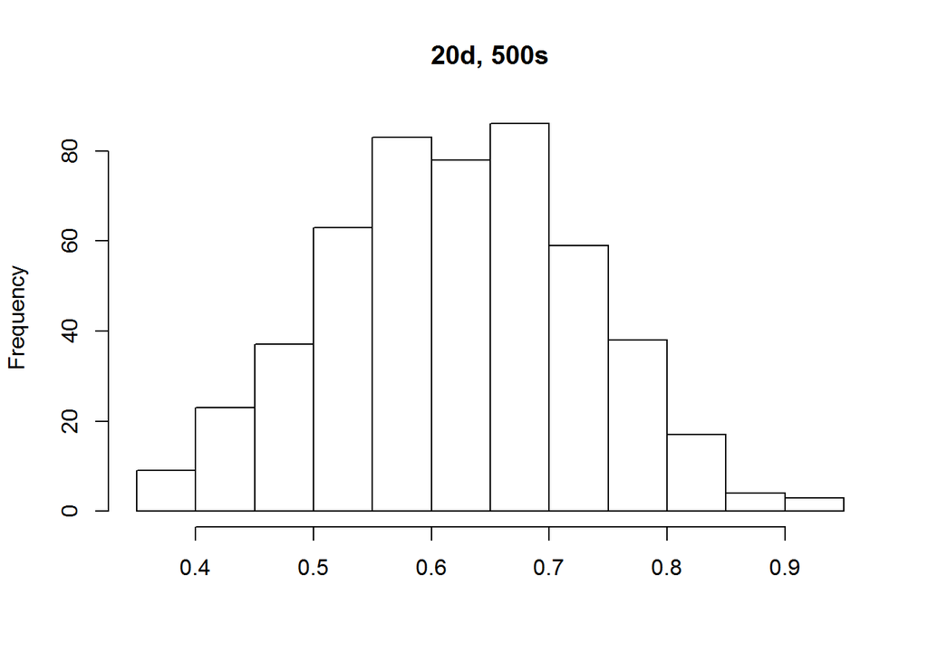

```r
# 20 draws repeated 500 times
hist(replicate(500,mean(sample(cflip,20,replace=T))),main='20d, 500s',xlab='')
```

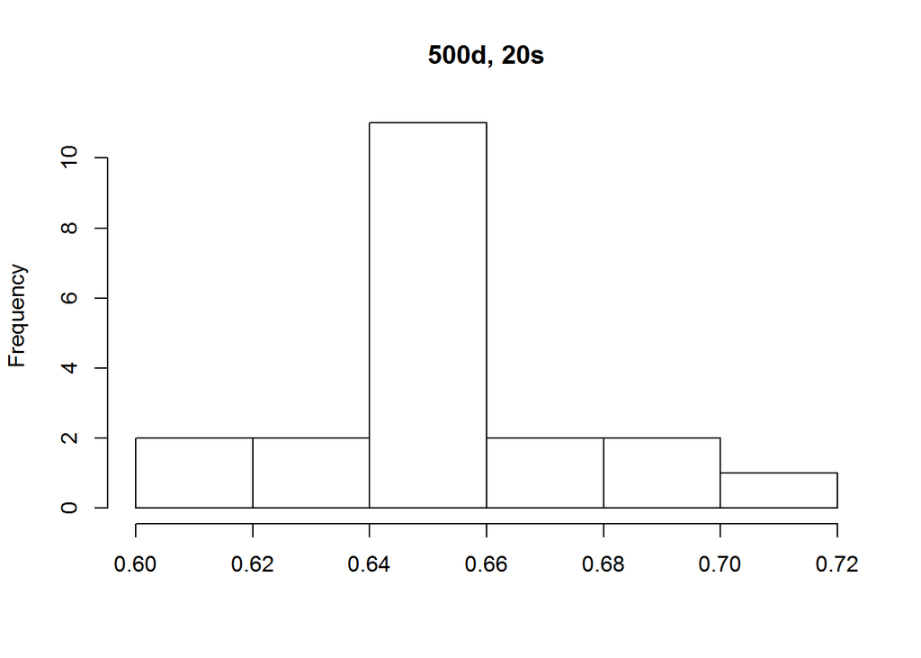

```r
# 500 draws repeated 20 times
hist(replicate(20,mean(sample(cflip,500,replace=T))),main='500d, 20s',xlab='')
```